# Data Science II Midterm

Arghya Kannadaguli (ak5357), Carolina Montes Garcia (cm3341), Fang Wang (fw2394)

2025-03-25

## **Assignment Description**

A researcher conducted a study to evaluate antibody responses to a newly authorized vaccine. Understanding antibody responses can help inform vaccine effectiveness and identify populations with weaker immune responses. The antibody level measured via dry blood spot (log-transformed) is the primary outcome of interest. The researcher also collected data on potential predictors to understand factors influencing the antibody response. Here is a description of the dataset (dat1.RData):

[output not shown]

Using this dataset, the researcher planned to build a prediction model of antibody levels, aiming to understand how demographic and clinical factors influence antibody responses and how antibody levels change over time following vaccination. Please help the researcher build this model.

A few months after the initial data collection, the researcher collected a new, independent dataset (dat2.RData) with the same structure as dat1.RData. Evaluate the robustness and generalizability of your prediction model using the new dataset. Does the model generalize well to this new dataset? If the model does not generalize well, discuss possible reasons.

## **Setup**

```r
# LOAD LIBRARIES
library(tidyverse)
library(dplyr)
library(ggplot2)
library(pdp)
library(gt)
library(gtsummary)
library(ggpubr)
library (caret)
library(mgcv)
library(earth)
library(tidyverse)
library(rsample)

# KNIT SETTINGS
knitr::opts_chunk$set(
  message = FALSE,
  warning = FALSE,
  out.width = "90%",
  fig.align = "center"
)

# FIGURE SETTINGS
theme_set(
  theme(
    #legend.position = "bottom",
    plot.title = element_text(hjust = 0.5, margin = margin(b = 5), face = "bold"),
    plot.subtitle = element_text(hjust = 0.5, margin = margin(b = 10), color = "azure4", face = "bold", size = 8)
  )
)
```

##### **Load Data**

```r
load("data/dat1.RData")
load("data/dat2.RData")

dat1 = as_tibble(dat1) |>
  janitor::clean_names() |>
  mutate(across(c(gender, race, smoking, hypertension, diabetes), as.factor))

dat2 = as_tibble(dat2) |>
  janitor::clean_names() |>
  mutate(across(c(gender, race, smoking, hypertension, diabetes), as.factor))

dat1_decoded = dat1 |>
  mutate(
    across(c(gender, race, smoking, hypertension, diabetes), as.character),
    across(c(gender, race, smoking, hypertension, diabetes), as.numeric),
    gender = factor(case_match(gender, 0 ~ "Female", 1 ~ "Male"), levels = c("Female", "Male")),
    race = factor(case_match(race, 1 ~ "White", 2 ~ "Asian", 3 ~ "Black", 4 ~ "Hispanic"), levels = c("White", "Asian", "Black", "Hispanic")),
    smoking = factor(case_match(smoking, 0 ~ "Never smoked", 1 ~ "Former smoker", 2 ~ "Current smoker"), levels = c("Never smoked", "Former smoker", "Current smoker")),
    hypertension = factor(case_match(hypertension, 0 ~ "No", 1 ~ "Yes"), levels = c("No", "Yes")),
    diabetes = factor(case_match(diabetes, 0 ~ "No", 1 ~ "Yes"), levels = c("No", "Yes"))
  )

head(dat1_decoded, 5) |>
  knitr::kable(digits = 2)
```

| id | age | gender | race | smoking | height | weight | bmi | diabetes | hypertension | sbp | ldl | time | log_antibody |
| --- | --- | --- | --- | --- | --- | --- | --- | --- | --- | --- | --- | --- | --- |
| 1 | 50 | Female | White | Never smoked | 176.1 | 68.3 | 22.0 | No | No | 130 | 82 | 76 | 10.65 |
| 2 | 71 | Male | White | Never smoked | 175.7 | 69.6 | 22.6 | No | Yes | 149 | 129 | 82 | 9.89 |
| 3 | 58 | Male | White | Former smoker | 168.7 | 76.9 | 27.0 | No | No | 127 | 101 | 168 | 10.90 |
| 4 | 63 | Female | White | Never smoked | 167.4 | 90.0 | 32.1 | No | Yes | 138 | 93 | 105 | 9.91 |
| 5 | 56 | Male | White | Never smoked | 162.7 | 83.9 | 31.7 | No | No | 123 | 97 | 193 | 9.56 |

## **General Exploratory Data Analysis (EDA)**

##### **Summary Statistics**

```r
dat1_decoded |>
  select(-id) |>
  tbl_summary(
    statistic = list (all_continuous() ~ "{min} - {max} | Mean: {mean} (SD: {sd})",
                      all_categorical() ~ "{n} ({p}%)"),
    label = list(
      id = "ID (id)",
      age = "Age (age) ",
      gender = "Gender (gender)",
      race = "Race/ethnicity (race)",
      smoking = "Smoking (smoking)",
      height = "Height (height)",
      weight = "Weight (weight)",
      bmi = "BMI (bmi)",
      diabetes = "Diabetes (diabetes)",
      hypertension = "Hypertension (hypertension)",
      sbp = "Systolic blood pressure (sbp)",
      ldl = "LDL cholesterol (ldl)",
      time = "Time since vaccination (time)",
      log_antibody = "Log-transformed antibody level (log_antibody)"
    )
  ) |>
  modify_caption("**Summary Statistics for Dataset 1**") #|>
```

**Summary Statistics for Dataset 1**

| **Characteristic** | **N = 5,000**<sup>1</sup> |
| --- | --- |
| Age (age) | 44.0 - 75.0 \| Mean: 60.0 (SD: 4.5) |
| Gender (gender) |  |
| Female | 2,573 (51%) |
| Male | 2,427 (49%) |
| Race/ethnicity (race) |  |
| White | 3,221 (64%) |
| Asian | 278 (5.6%) |
| Black | 1,036 (21%) |
| Hispanic | 465 (9.3%) |
| Smoking (smoking) |  |
| Never smoked | 3,010 (60%) |
| Former smoker | 1,504 (30%) |
| Current smoker | 486 (9.7%) |
| Height (height) | 150.2 - 192.9 \| Mean: 170.1 (SD: 5.9) |
| Weight (weight) | 57 - 106 \| Mean: 80 (SD: 7) |
| BMI (bmi) | 18.20 - 38.80 \| Mean: 27.74 (SD: 2.76) |
| Diabetes (diabetes) | 772 (15%) |
| Hypertension (hypertension) | 2,298 (46%) |
| Systolic blood pressure (sbp) | 101 - 155 \| Mean: 130 (SD: 8) |
| LDL cholesterol (ldl) | 43 - 185 \| Mean: 110 (SD: 20) |
| Time since vaccination (time) | 30 - 270 \| Mean: 109 (SD: 43) |
| Log-transformed antibody level (log_antibody) | 7.77 - 11.96 \| Mean: 10.06 (SD: 0.60) |

<sup>1</sup> Min - Max | Mean: Mean (SD: SD); n (%)

```r
  # as_gt() |>
  # gtsave("figures/summary_table.png")
```

##### **Univariate Plots**

**Categorical Variable Barplots**

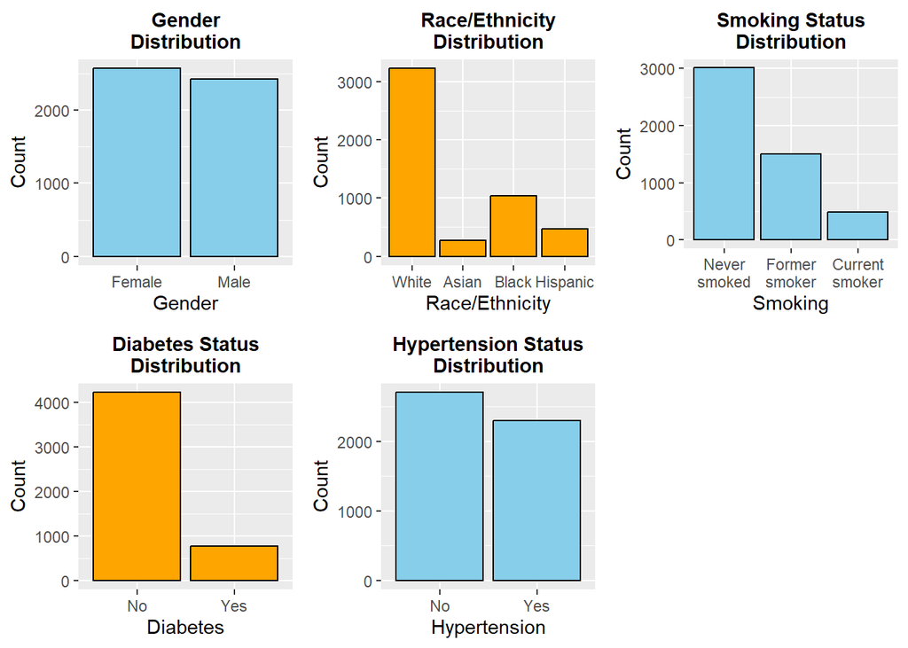

```r
p_gender = ggplot(dat1_decoded, aes(x = gender)) +
  geom_bar(fill = "skyblue", color = "black", lwd = 0.5) +
  labs(title = "Gender\nDistribution", x = "Gender", y = "Count")

p_race = ggplot(dat1_decoded, aes(x = race)) +
  geom_bar(fill= "orange", color = "black", lwd = 0.5) +
  labs(title = "Race/Ethnicity\nDistribution", x = "Race/Ethnicity", y = "Count")

p_smoking = dat1_decoded |>
  mutate(smoking = fct_rev(as.factor(str_replace(smoking, " ", "\n")))) |>
  ggplot(aes(x = smoking)) +
  geom_bar(fill = "skyblue", color = "black", lwd = 0.5) +
  labs(title = "Smoking Status\nDistribution", x = "Smoking", y = "Count")

p_diabetes = ggplot(dat1_decoded, aes(x = diabetes)) +
  geom_bar(fill = "orange", color = "black", lwd = 0.5) +
  labs(title = "Diabetes Status\nDistribution", x = "Diabetes", y = "Count")

p_hypertension = ggplot(dat1_decoded, aes(x = hypertension)) +
  geom_bar(fill = "skyblue", color = "black", lwd = 0.5) +
  labs(title = "Hypertension Status\nDistribution", x = "Hypertension", y = "Count")

barplot_combined = ggarrange(p_gender, p_race, p_smoking, p_diabetes, p_hypertension, nrow = 2, ncol = 3)

barplot_combined
```

**Numeric Variable Histograms**

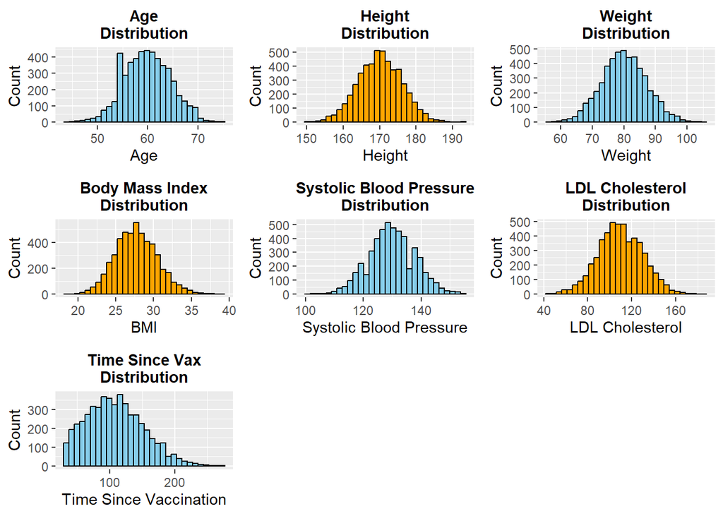

```r
p_age = ggplot(dat1_decoded, aes(x = age)) +
  geom_histogram(fill = "skyblue", color = "black", lwd = 0.5) +
  labs(title = "Age\nDistribution", x = "Age", y = "Count")

p_height = ggplot(dat1_decoded, aes(x = height)) +
  geom_histogram(fill = "orange", color = "black", lwd = 0.5) +
  labs(title = "Height\nDistribution", x = "Height", y = "Count")

p_weight = ggplot(dat1_decoded, aes(x = weight)) +
  geom_histogram(fill = "skyblue", color = "black", lwd = 0.5) +
  labs(title = "Weight\nDistribution", x = "Weight", y = "Count")

p_bmi = ggplot(dat1_decoded, aes(x = bmi)) +
  geom_histogram(fill = "orange", color = "black", lwd = 0.5) +
  labs(title = "Body Mass Index\nDistribution", x = "BMI", y = "Count")

p_sbp = ggplot(dat1_decoded, aes(x = sbp)) +
  geom_histogram(fill = "skyblue", color = "black", lwd = 0.5) +
  labs(title = "Systolic Blood Pressure\nDistribution", x = "Systolic Blood Pressure", y = "Count")

p_ldl = ggplot(dat1_decoded, aes(x = ldl)) +
  geom_histogram(fill = "orange", color = "black", lwd = 0.5) +
  labs(title = "LDL Cholesterol\nDistribution", x = "LDL Cholesterol", y = "Count")

p_time = ggplot(dat1_decoded, aes(x = time)) +
  geom_histogram(fill = "skyblue", color = "black", lwd = 0.5) +
  labs(title = "Time Since Vax\nDistribution", x = "Time Since Vaccination", y = "Count")

histogram_combined = ggarrange(p_age, p_height, p_weight, p_bmi, p_sbp, p_ldl, p_time, nrow = 3, ncol = 3)

histogram_combined
```

## **Post-Split EDA**

##### **Split Dataset**

```r
# split dataset into training data and testing data:
set.seed(2025)
data_split = initial_split(dat1, prop =0.8)
training_data = training (data_split)
testing_data = testing (data_split)
# Cross-validation setup:
ctrl1 = trainControl(method = "cv", number = 10)
```

##### **Bivariate Plots**

**Density Plots of Response Variable by Categorical Variables**

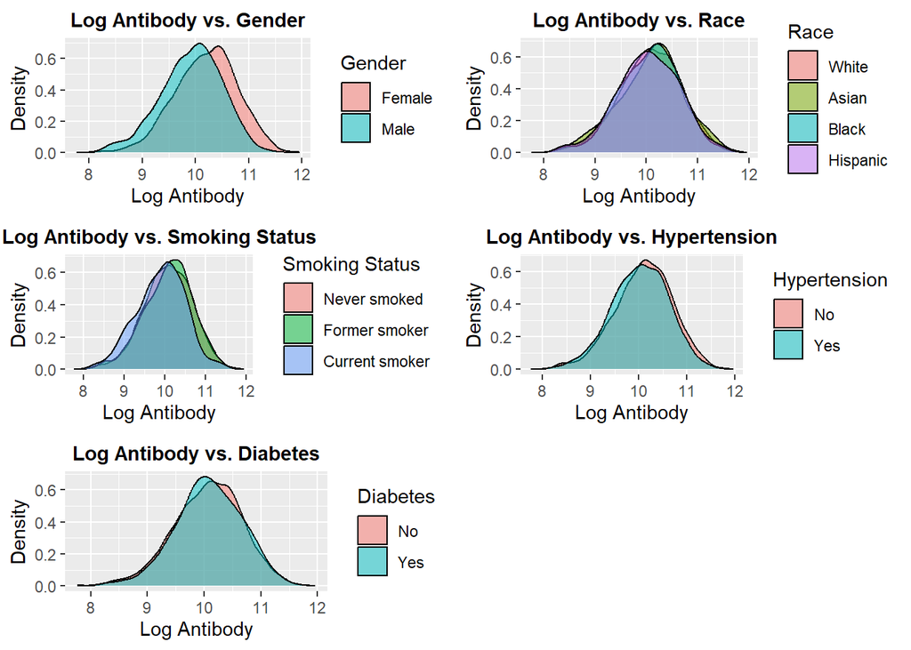

```r
# Create function for plot generation
cat_plot = function(var, label, df = dat1_decoded){
  output_plot = df |>
    ggplot(aes(x = log_antibody, fill = !!sym(var))) +
    geom_density(alpha = 0.5, lwd = 0.5) +
    labs(
      title = paste0("Log Antibody vs. ", label),
      x = "Log Antibody",
      y = "Density",
      fill = label
    )

  return(output_plot)
}

training_data_decoded = dat1_decoded |>
  filter(id %in% training_data$id)

# Generate Plots
gender_plot = cat_plot("gender", "Gender", training_data_decoded)
race_plot = cat_plot("race", "Race", training_data_decoded)
smoking_plot = cat_plot("smoking", "Smoking Status", training_data_decoded)
hypertension_plot = cat_plot("hypertension", "Hypertension", training_data_decoded)
diabetes_plot = cat_plot("diabetes", "Diabetes", training_data_decoded)

# Display multi-plot figure (manually exporting to save multi-plot figure)
cat_vars_plot = ggarrange(gender_plot, race_plot, smoking_plot, hypertension_plot, diabetes_plot, nrow = 3, ncol = 2)
cat_vars_plot
```

**Trellis Plots for Numeric Variables**

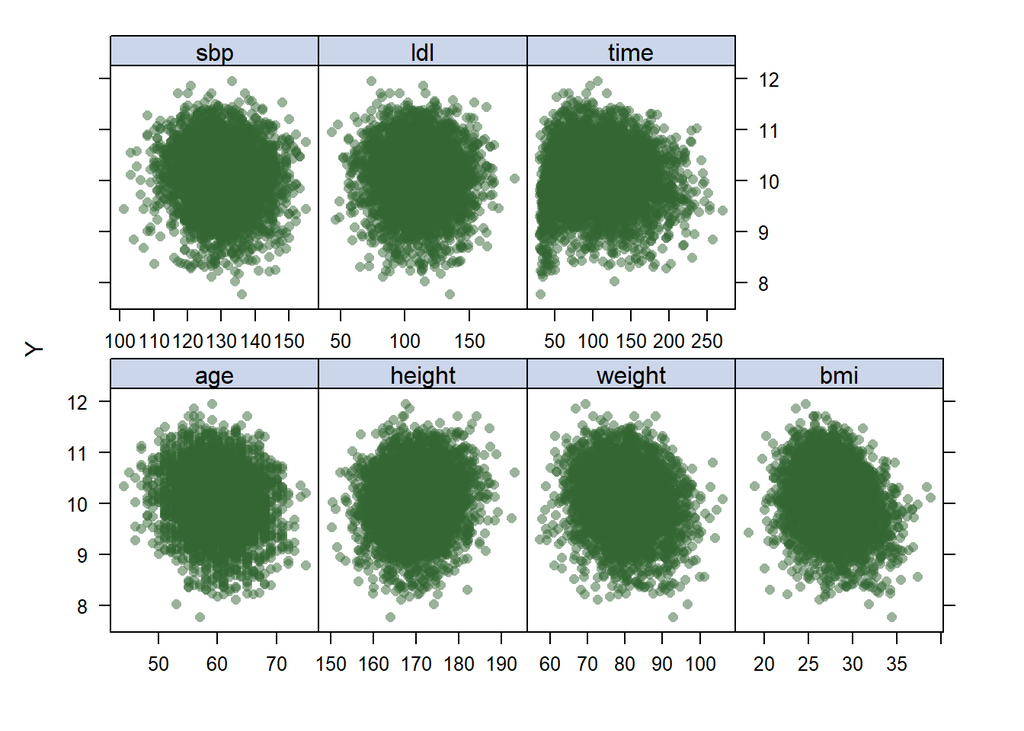

```r
theme1 = trellis.par.get()
theme1$plot.symbol$col <- rgb(.2, .4, .2, .5)
theme1$plot.symbol$pch <- 16
theme1$plot.line$col <- rgb(.8, .1, .1, 1)
theme1$plot.line$lwd <- 2
theme1$strip.background$col <- rgb(.0, .2, .6, .2)
trellis.par.set(theme1)
featurePlot(x = training_data[, c("age", "height", "weight", "bmi", "sbp", "ldl", "time")], training_data$log_antibody, plot = "scatter", labels = c("", "Y"),
type = c("p"), layout = c(4, 2)) #ncol, nrow
```

**Scatterplots for Response with Numeric Variables**

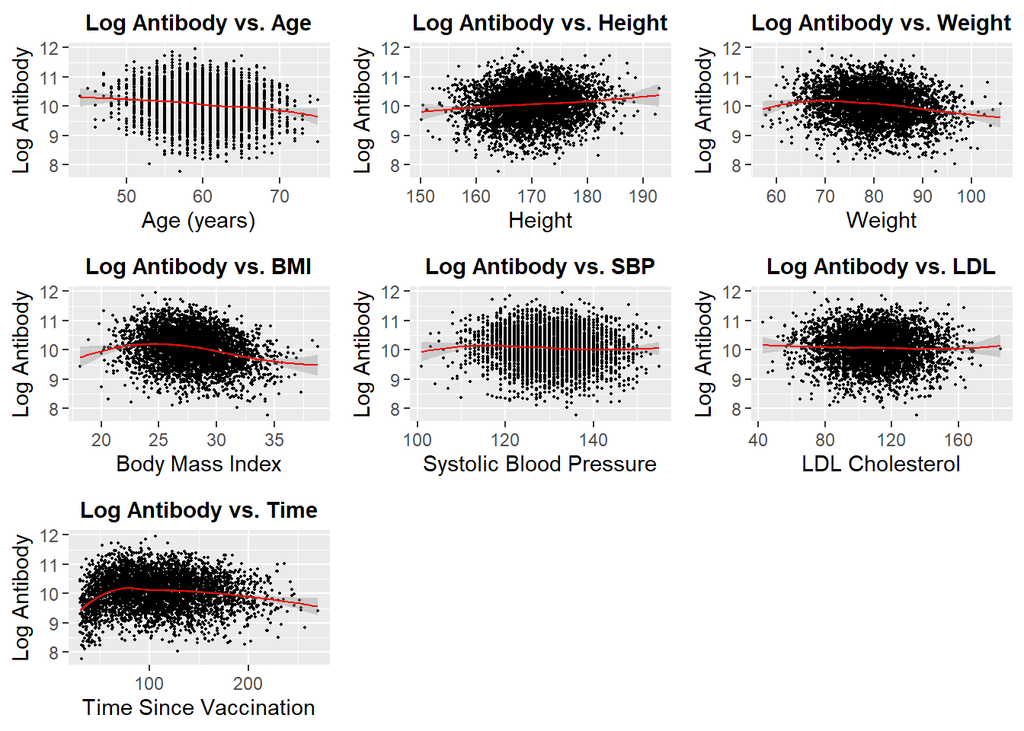

```r
# Create function for plot generation
num_plot = function(var, label, xlab, df = dat1){
  output_plot = df |>
    ggplot(aes(x = !!sym(var), y = log_antibody)) +
    geom_point(size = 0.3) +
    geom_smooth(lwd = 0.5, method = "loess", color = "red") +
    labs(
      title = paste0("Log Antibody vs. ", label),
      x = xlab,
      y = "Log Antibody"
    )

  return(output_plot)
}

# Generate Plots
age_plot = num_plot("age", "Age", "Age (years)", training_data)
height_plot = num_plot("height", "Height", "Height", training_data)
weight_plot = num_plot("weight", "Weight", "Weight", training_data)
bmi_plot = num_plot("bmi", "BMI", "Body Mass Index", training_data)
sbp_plot = num_plot("sbp", "SBP", "Systolic Blood Pressure", training_data)
ldl_plot = num_plot("ldl", "LDL", "LDL Cholesterol", training_data)
time_plot = num_plot("time", "Time", "Time Since Vaccination", training_data)

# Display multi-plot figure (manually exporting to save multi-plot figure)
cont_vars_plot = ggarrange(age_plot, height_plot, weight_plot, bmi_plot, sbp_plot, ldl_plot, time_plot, nrow = 3, ncol= 3)
cont_vars_plot
```

##### **Correlation Plot**

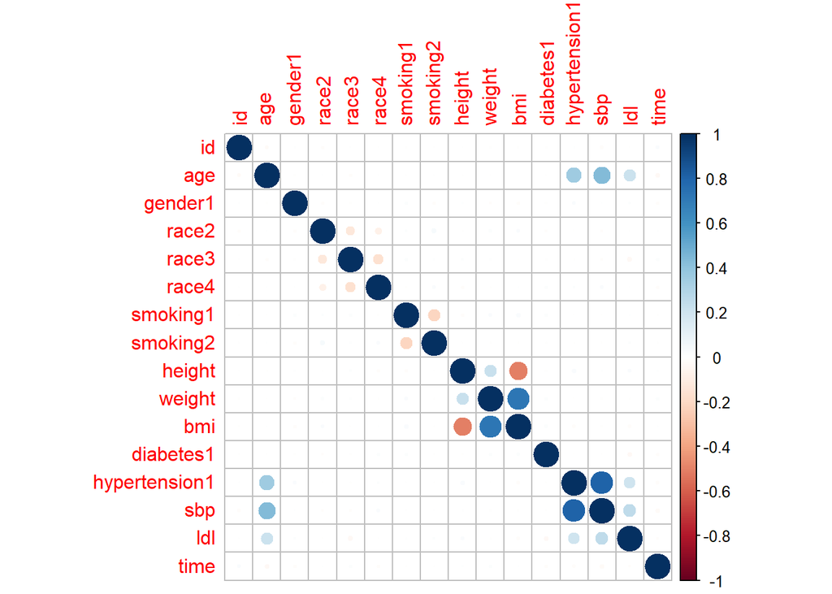

```r
dat1_x_matrix = model.matrix(log_antibody ~ ., data = dat1)[, -1]
corrplot::corrplot(cor(dat1_x_matrix), method = "circle", type = "full")
```

## **Model Training**

##### **Create Model Matrix**

```r
# training_data
x = model.matrix(log_antibody~ .- id, training_data)[,-1] #remove the first column
y = training_data$log_antibody
```

##### **1: Basic OLS Model**

Train model.

```r
set.seed(2025)
lm_fit = train(
  x = x,
  y = y,
  method = "lm",
  trControl = ctrl1
)

summary(lm_fit)
```

```
##
## Call:
## lm(formula = .outcome ~ ., data = dat)
##
## Residuals:
##      Min       1Q   Median       3Q      Max
## -2.13252 -0.36104  0.03452  0.38629  1.65908
##
## Coefficients:
##                 Estimate Std. Error t value Pr(>|t|)
## (Intercept)    2.560e+01  2.587e+00   9.896  < 2e-16 ***
## age           -1.916e-02  2.195e-03  -8.727  < 2e-16 ***
## gender1       -2.930e-01  1.760e-02 -16.647  < 2e-16 ***
## race2          1.551e-02  3.839e-02   0.404    0.686
## race3         -1.499e-02  2.223e-02  -0.674    0.500
## race4         -3.822e-02  3.042e-02  -1.256    0.209
## smoking1       2.133e-02  1.966e-02   1.085    0.278
## smoking2      -1.856e-01  3.081e-02  -6.024 1.86e-09 ***
## height        -7.582e-02  1.514e-02  -5.008 5.74e-07 ***
## weight         7.922e-02  1.604e-02   4.939 8.16e-07 ***
## bmi           -2.784e-01  4.616e-02  -6.032 1.77e-09 ***
## diabetes1      1.187e-02  2.432e-02   0.488    0.625
## hypertension1 -2.368e-02  2.944e-02  -0.804    0.421
## sbp            7.223e-04  1.925e-03   0.375    0.708
## ldl           -3.402e-05  4.547e-04  -0.075    0.940
## time          -2.516e-04  2.033e-04  -1.237    0.216
## ---
## Signif. codes:  0 '***' 0.001 '**' 0.01 '*' 0.05 '.' 0.1 ' ' 1
##
## Residual standard error: 0.5551 on 3984 degrees of freedom
## Multiple R-squared:  0.1428, Adjusted R-squared:  0.1395
## F-statistic: 44.23 on 15 and 3984 DF,  p-value: < 2.2e-16
```

Visualize model.

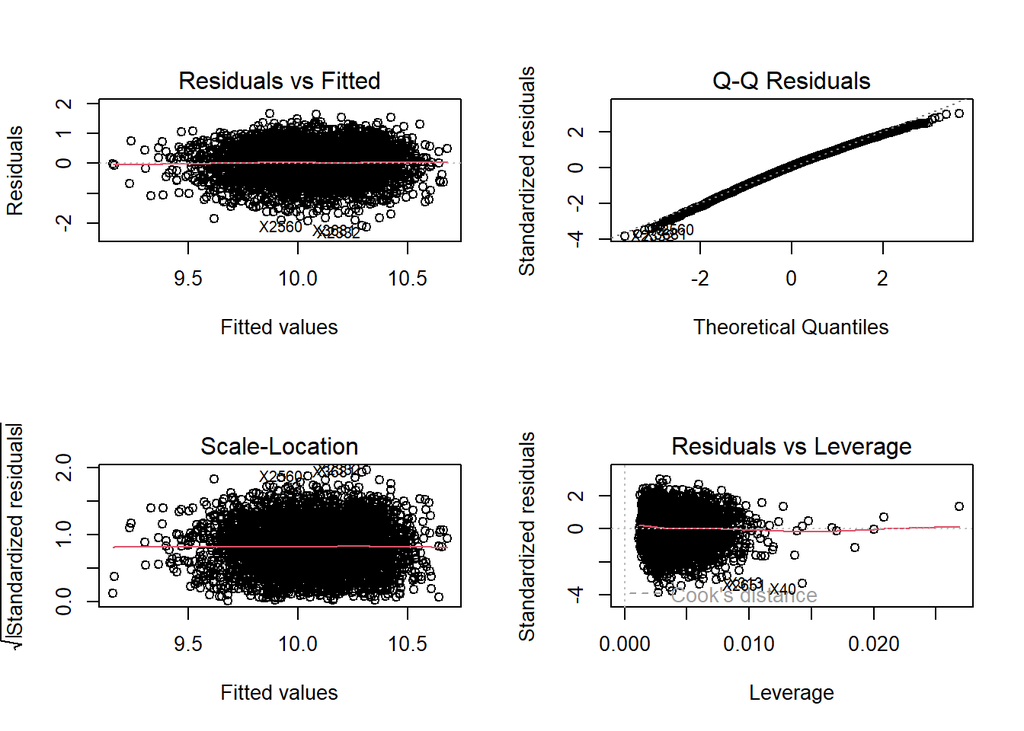

```r
par(mfrow = c(2, 2))  # Arrange plots in 2x2 layout
plot(lm_fit$finalModel)  # Diagnostic plots
```

##### **2: Elastic Net**

Train model.

```r
set.seed(2025)
enet_fit = train(
    x = x,
    y = y,
    method = "glmnet",
    tuneGrid = expand.grid(
        alpha = seq(0, 1, length = 21),
        lambda = exp(seq(9, -3, length = 100))
    ),
    trControl = ctrl1
)

summary(enet_fit)
```

```
##             Length Class      Mode
## a0           100   -none-     numeric
## beta        1500   dgCMatrix  S4
## df           100   -none-     numeric
## dim            2   -none-     numeric
## lambda       100   -none-     numeric
## dev.ratio    100   -none-     numeric
## nulldev        1   -none-     numeric
## npasses        1   -none-     numeric
## jerr           1   -none-     numeric
## offset         1   -none-     logical
## call           5   -none-     call
## nobs           1   -none-     numeric
## lambdaOpt      1   -none-     numeric
## xNames        15   -none-     character
## problemType    1   -none-     character
## tuneValue      2   data.frame list
## obsLevels      1   -none-     logical
## param          0   -none-     list
```

Optimal tuning parameter.

```r
enet_fit$bestTune
```

```
##     alpha     lambda
## 101  0.05 0.04978707
```

Visualize training process.

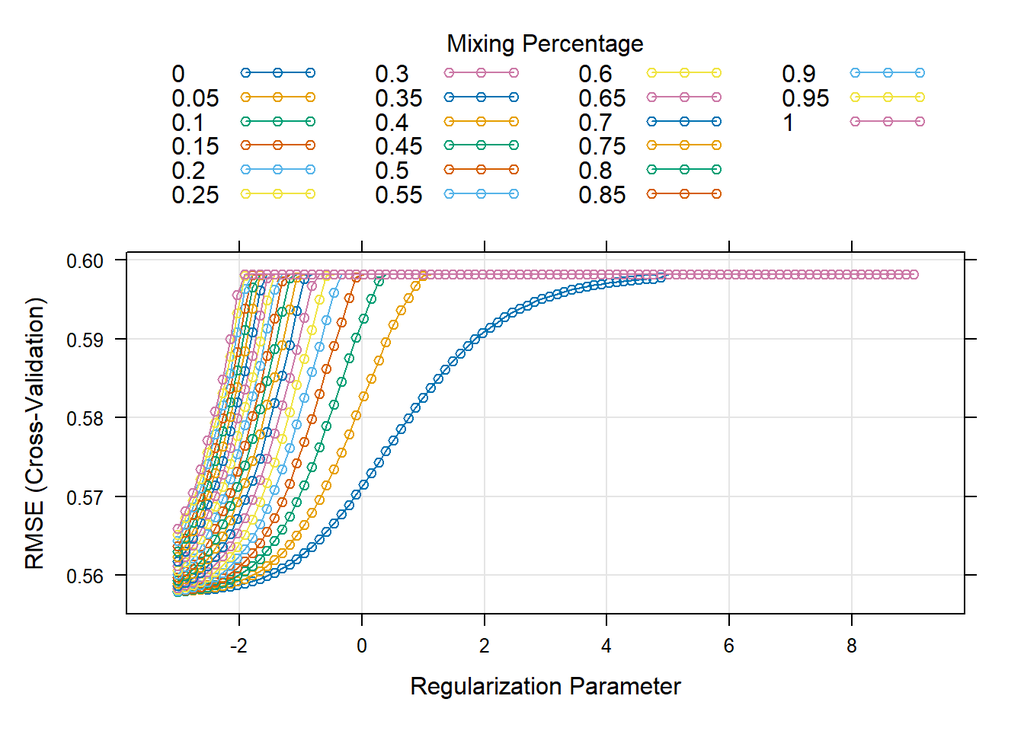

```r
par(mfrow = c(1, 1)) # reset plotting grid afterwards
plot(enet_fit, xTrans = log)
```

##### **3: Partial Least Squares**

```r
set.seed(2025)
pls_fit = train(x, y,
  method = "pls",
  tuneGrid = data.frame(ncomp = 1:14),
  trControl = ctrl1,
  preProcess = c("center", "scale"))

summary(pls_fit)
```

```
## Data:    X dimension: 4000 15
##  Y dimension: 4000 1
## Fit method: oscorespls
## Number of components considered: 9
## TRAINING: % variance explained
##           1 comps  2 comps  3 comps  4 comps  5 comps  6 comps  7 comps
## X           10.82    20.03    31.90    38.41    44.38    47.50    53.54
## .outcome    12.17    13.53    13.62    13.64    13.65    13.68    13.73
##           8 comps  9 comps
## X           55.17    60.65
## .outcome    14.18    14.27
```

Optimal tuning parameter.

```r
pls_fit$bestTune$ncomp #best_ncomp
```

```
## [1] 9
```

Visualize training process.

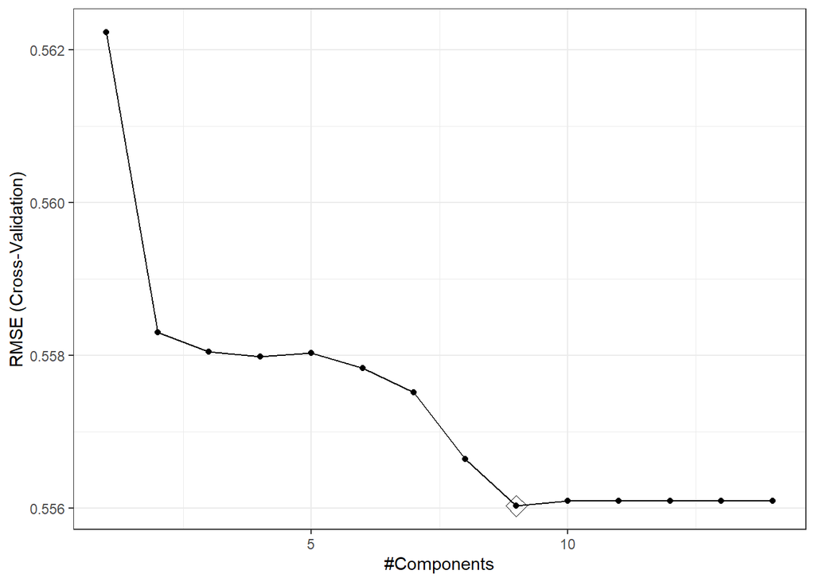

```r
ggplot(pls_fit, highlight = TRUE) + theme_bw()
```

##### **4: Generalized Additive Model (GAM)**

Train Model.

```r
set.seed(2025)
gam_fit = train(
  log_antibody ~ age + height + weight + bmi + sbp + ldl + time + gender + race + smoking + diabetes + hypertension,
  data = training_data,
  method = "gam",
  trControl = ctrl1
)

summary(gam_fit)
```

```
##
## Family: gaussian
## Link function: identity
##
## Formula:
## .outcome ~ gender1 + race2 + race3 + race4 + smoking1 + smoking2 +
##     diabetes1 + hypertension1 + s(age) + s(sbp) + s(ldl) + s(bmi) +
##     s(time) + s(height) + s(weight)
##
## Parametric coefficients:
##               Estimate Std. Error t value Pr(>|t|)
## (Intercept)   10.23186    0.01730 591.581  < 2e-16 ***
## gender1       -0.29203    0.01684 -17.342  < 2e-16 ***
## race2          0.02400    0.03673   0.653    0.514
## race3         -0.01732    0.02127  -0.814    0.416
## race4         -0.03298    0.02911  -1.133    0.257
## smoking1       0.01931    0.01881   1.026    0.305
## smoking2      -0.18483    0.02948  -6.269 4.01e-10 ***
## diabetes1      0.01712    0.02324   0.736    0.462
## hypertension1 -0.02241    0.01802  -1.243    0.214
## ---
## Signif. codes:  0 '***' 0.001 '**' 0.01 '*' 0.05 '.' 0.1 ' ' 1
##
## Approximate significance of smooth terms:
##                 edf Ref.df      F p-value
## s(age)    9.833e-01      9  9.564  <2e-16 ***
## s(sbp)    2.352e-06      9  0.000   0.701
## s(ldl)    1.547e-06      9  0.000   0.970
## s(bmi)    3.411e+00      9 31.958  <2e-16 ***
## s(time)   8.177e+00      9 36.772  <2e-16 ***
## s(height) 1.597e+00      9  0.288   0.179
## s(weight) 2.718e-06      9  0.000   0.880
## ---
## Signif. codes:  0 '***' 0.001 '**' 0.01 '*' 0.05 '.' 0.1 ' ' 1
##
## R-sq.(adj) =  0.214   Deviance explained = 21.8%
## GCV = 0.28318  Scale est. = 0.28154   n = 4000
```

Optimal model.

```r
model_gam = gam_fit$finalModel
```

Visualize model tuning.

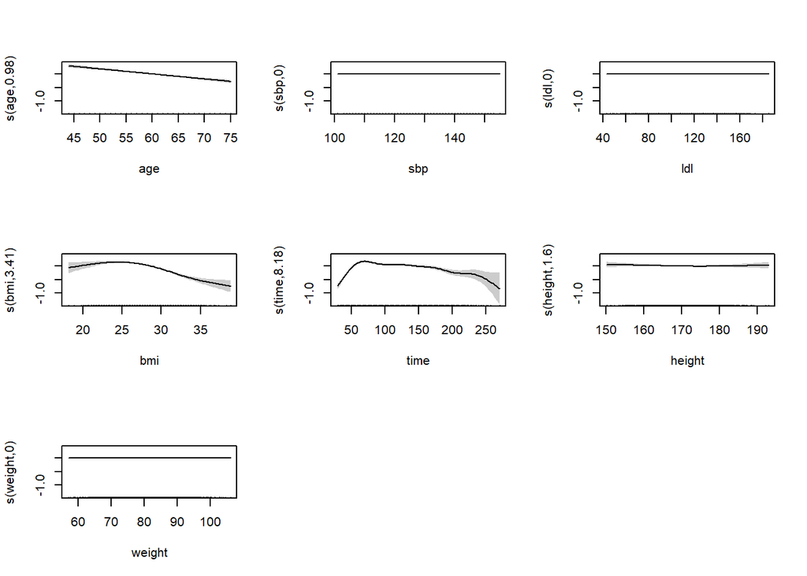

```r
plot(model_gam, pages = 1, shade = TRUE, seWithMean = TRUE)
```

# **5: MARS**

```r
set.seed(2025)
mars_grid = expand.grid(degree = 1:4, nprune = 2:20)
mars_fit = train(x, y,
                  method = "earth",
                  tuneGrid = mars_grid,
                  trControl = ctrl1)

summary(mars_fit)
```

```
## Call: earth(x=matrix[4000,15], y=c(10.82,10.33,9...), keepxy=TRUE, degree=1,
##             nprune=8)
##
##             coefficients
## (Intercept)   10.3615208
## gender1       -0.2907860
## smoking2      -0.1929607
## h(70-age)      0.0197389
## h(26.1-bmi)   -0.0192092
## h(bmi-26.1)   -0.0723857
## h(57-time)    -0.0339077
## h(time-57)    -0.0022956
##
## Selected 8 of 16 terms, and 5 of 15 predictors (nprune=8)
## Termination condition: RSq changed by less than 0.001 at 16 terms
## Importance: bmi, gender1, time, age, smoking2, race2-unused, race3-unused, ...
## Number of terms at each degree of interaction: 1 7 (additive model)
## GCV 0.2838832    RSS 1127.032    GRSq 0.2073858    RSq 0.2129258
```

Optimal tuning parameters.

```r
mars_fit$bestTune # nprune: 8; degree: 1
```

```
##   nprune degree
## 7      8      1
```

Optimal model.

```r
coef(mars_fit$finalModel)
```

```
##  (Intercept)   h(time-57)   h(57-time)  h(bmi-26.1)  h(26.1-bmi)      gender1
## 10.361520827 -0.002295613 -0.033907689 -0.072385665 -0.019209240 -0.290785998
##    h(70-age)     smoking2
##  0.019738906 -0.192960736
```

Visualize.

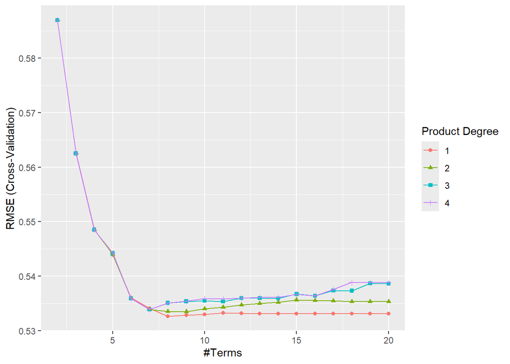

```r
ggplot(mars_fit)
```

## **Model Selection**

##### **Comparing Models**

```r
resamp = resamples(list(OLS = lm_fit,
                        ENET = enet_fit,
                        PLS = pls_fit,
                        GAM = gam_fit,
                        MARS = mars_fit))
summary(resamp)
```

```
##
## Call:
## summary.resamples(object = resamp)
##
## Models: OLS, ENET, PLS, GAM, MARS
## Number of resamples: 10
##
## MAE
##           Min.   1st Qu.    Median      Mean   3rd Qu.      Max. NA's
## OLS  0.4283438 0.4376430 0.4438661 0.4445266 0.4503930 0.4652542    0
## ENET 0.4298117 0.4362280 0.4451915 0.4456259 0.4554273 0.4626619    0
## PLS  0.4282670 0.4376162 0.4438702 0.4444897 0.4502990 0.4650673    0
## GAM  0.4154035 0.4185303 0.4236603 0.4271905 0.4343344 0.4468299    0
## MARS 0.4126603 0.4200190 0.4227874 0.4273263 0.4351431 0.4515943    0
##
## RMSE
##           Min.   1st Qu.    Median      Mean   3rd Qu.      Max. NA's
## OLS  0.5386739 0.5453977 0.5557110 0.5560978 0.5632708 0.5835946    0
## ENET 0.5394096 0.5491618 0.5594524 0.5579187 0.5649151 0.5811954    0
## PLS  0.5387438 0.5453223 0.5555832 0.5560305 0.5633028 0.5833137    0
## GAM  0.5233082 0.5257905 0.5281670 0.5324599 0.5371696 0.5546132    0
## MARS 0.5243430 0.5262920 0.5284835 0.5326417 0.5357969 0.5592904    0
##
## Rsquared
##            Min.   1st Qu.    Median      Mean   3rd Qu.      Max. NA's
## OLS  0.08736256 0.1178073 0.1330346 0.1382936 0.1601209 0.2113563    0
## ENET 0.08624607 0.1148516 0.1291217 0.1327305 0.1474481 0.1996434    0
## PLS  0.08785355 0.1182688 0.1327992 0.1384697 0.1599674 0.2114380    0
## GAM  0.16609319 0.1777414 0.2137100 0.2090857 0.2337162 0.2545440    0
## MARS 0.16042244 0.1760538 0.2174136 0.2085667 0.2325809 0.2514842    0
```

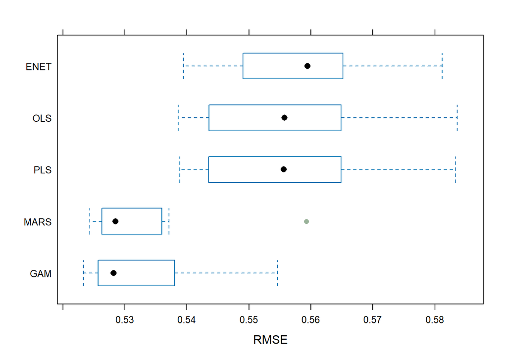

```r
bwplot(resamp, metric = "RMSE")
```

##### **GAM Model performs best.**

## **Estimating Generalizability**

```r
test_x = model.matrix(log_antibody ~ ., testing_data)[, -1]
gam_pred_dat1 = predict(gam_fit, newdata = testing_data)
gam_rmse_dat1 = sqrt(mean((gam_pred_dat1 - testing_data$log_antibody)^2))

gam_rmse_dat1
```

```
## [1] 0.5121094
```

## **Assessing Generalizability**

```r
dat2_x = model.matrix(log_antibody ~ ., dat2)[, -1]
gam_pred_dat2 = predict(gam_fit, newdata = dat2)
gam_rmse_dat2 = sqrt(mean((gam_pred_dat2 - dat2$log_antibody)^2))

gam_rmse_dat2
```

```
## [1] 0.543914
```